# Part B. Analysis of house price data

Note: A few of the exercises might require to study some functionalities of packages such as `dplyr`. One great source is the book `R for Data Science` by Wickham and Grolemund https://r4ds.had.co.nz/.

```r
suppressMessages(library(dplyr))
suppressMessages(library(zoo))
suppressMessages(library(tidyverse))
suppressMessages(library(readr))
```

The file `rhpi.csv` contains data from the International House Price Database from the Federal Reserve Bank of Dallas. It records the real housing price index. Make sure to use this file `rhpi.csv` contained in the repo for your assignment. If you are interested in the topic beyond this assignment, the raw data is available [here](https://www.dallasfed.org/institute/houseprice/~/media/documents/institute/houseprice/hp1701.xlsx).

Open the `.csv` file into `R` and use `head()` to explore the first few rows of the dataset.

```r
ri_df <- read_csv("rhpi.csv")
```

[output not shown]

```r
#I know it should be "read.csv",but it will be a "X" before each year ,so I change it into "read_csv"
head(ri_df)
```

```
## # A tibble: 6 × 170
##   ...1   1975:…¹ 1975:…² 1975:…³ 1975:…⁴ 1976:…⁵ 1976:…⁶ 1976:…⁷ 1976:…⁸ 1977:…⁹
##   <chr>    <dbl>   <dbl>   <dbl>   <dbl>   <dbl>   <dbl>   <dbl>   <dbl>   <dbl>
## 1 Austr…    39.2    38.5    38.6    37.8    38.0    38.1    38.4    37.9    37.9
## 2 Belgi…    44.5    45.7    47.0    48.7    50.6    52.3    53.7    55.2    56.3
## 3 Canada    59.4    59.2    59.9    59.5    59.2    59.8    58.9    57.6    55.9
## 4 Switz…    93.8    91.8    90.4    88.9    86.8    85.9    85.0    85.2    84.5
## 5 Germa…   109.    108.    109.    109.    110.    111.    111.    113.    114.
## 6 Denma…    57.4    57.6    59.1    58.1    58.4    57.3    57.3    58.6    57.5
## # … with 160 more variables: `1977:Q2` <dbl>, `1977:Q3` <dbl>, `1977:Q4` <dbl>,
## #   `1978:Q1` <dbl>, `1978:Q2` <dbl>, `1978:Q3` <dbl>, `1978:Q4` <dbl>,
## #   `1979:Q1` <dbl>, `1979:Q2` <dbl>, `1979:Q3` <dbl>, `1979:Q4` <dbl>,
## #   `1980:Q1` <dbl>, `1980:Q2` <dbl>, `1980:Q3` <dbl>, `1980:Q4` <dbl>,
## #   `1981:Q1` <dbl>, `1981:Q2` <dbl>, `1981:Q3` <dbl>, `1981:Q4` <dbl>,
## #   `1982:Q1` <dbl>, `1982:Q2` <dbl>, `1982:Q3` <dbl>, `1982:Q4` <dbl>,
## #   `1983:Q1` <dbl>, `1983:Q2` <dbl>, `1983:Q3` <dbl>, `1983:Q4` <dbl>, …
```

1. You may find out that the first column name is empty. You can update the first column name to `country` by using the `colnames()` function.

```r
colnames(ri_df)[1] <- "Country"
head(ri_df)
```

```
## # A tibble: 6 × 170
##   Country     `1975:Q1` 1975:Q…¹ 1975:…² 1975:…³ 1976:…⁴ 1976:…⁵ 1976:…⁶ 1976:…⁷
##   <chr>           <dbl>    <dbl>   <dbl>   <dbl>   <dbl>   <dbl>   <dbl>   <dbl>
## 1 Australia        39.2     38.5    38.6    37.8    38.0    38.1    38.4    37.9
## 2 Belgium          44.5     45.7    47.0    48.7    50.6    52.3    53.7    55.2
## 3 Canada           59.4     59.2    59.9    59.5    59.2    59.8    58.9    57.6
## 4 Switzerland      93.8     91.8    90.4    88.9    86.8    85.9    85.0    85.2
## 5 Germany         109.     108.    109.    109.    110.    111.    111.    113.
## 6 Denmark          57.4     57.6    59.1    58.1    58.4    57.3    57.3    58.6
## # … with 161 more variables: `1977:Q1` <dbl>, `1977:Q2` <dbl>, `1977:Q3` <dbl>,
## #   `1977:Q4` <dbl>, `1978:Q1` <dbl>, `1978:Q2` <dbl>, `1978:Q3` <dbl>,
## #   `1978:Q4` <dbl>, `1979:Q1` <dbl>, `1979:Q2` <dbl>, `1979:Q3` <dbl>,
## #   `1979:Q4` <dbl>, `1980:Q1` <dbl>, `1980:Q2` <dbl>, `1980:Q3` <dbl>,
## #   `1980:Q4` <dbl>, `1981:Q1` <dbl>, `1981:Q2` <dbl>, `1981:Q3` <dbl>,
## #   `1981:Q4` <dbl>, `1982:Q1` <dbl>, `1982:Q2` <dbl>, `1982:Q3` <dbl>,
## #   `1982:Q4` <dbl>, `1983:Q1` <dbl>, `1983:Q2` <dbl>, `1983:Q3` <dbl>, …
```

2. Is it in long or wide format? Discuss why or why not it is a `tidy` dataset. If not, reshape the dataset such that it becomes *tidy*.

**ANSWER: Not a tidy format, because it too wide.**

```r
 ri_df_longer <- pivot_longer (ri_df, cols = colnames(ri_df)[2:length(colnames(ri_df))], names_to = "Year", values_to = "Price")

 ri_df_longer <- ri_df_longer %>%
   separate(Year,c("Year","Quarter"))

 head(ri_df_longer)
```

```
## # A tibble: 6 × 4
##   Country   Year  Quarter Price
##   <chr>     <chr> <chr>   <dbl>
## 1 Australia 1975  Q1       39.2
## 2 Australia 1975  Q2       38.5
## 3 Australia 1975  Q3       38.6
## 4 Australia 1975  Q4       37.8
## 5 Australia 1976  Q1       38.0
## 6 Australia 1976  Q2       38.1
```

**For the following exercises use the tidy version of the dataset.**

3. Only for this part, filter the data frame so that it only contains the data that correspond to the US. Then, produce a line plot that tracks the housing price over time. What do you find?

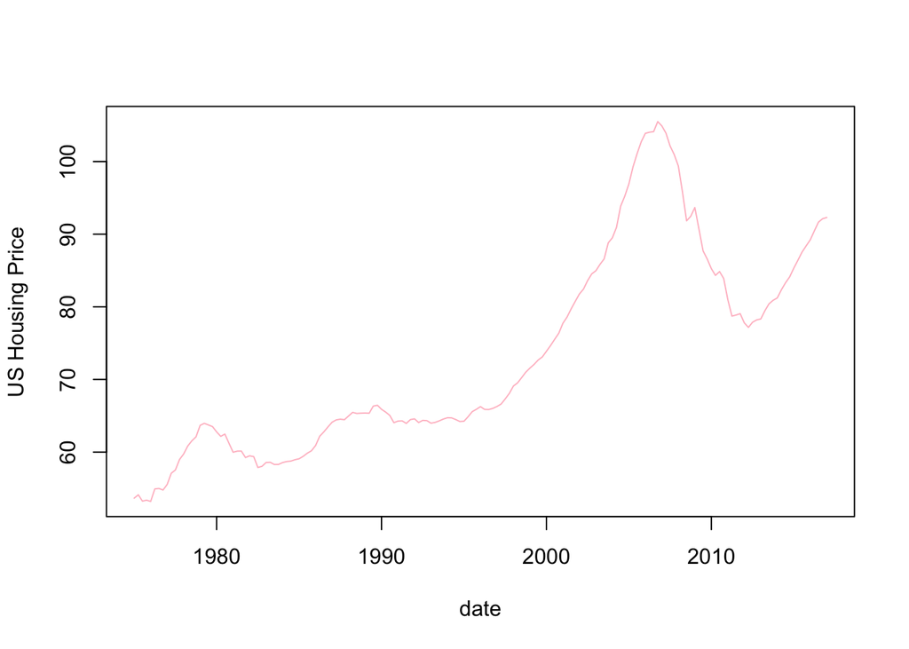

```r
ri_df_longer$date <- paste(ri_df_longer$Year,ri_df_longer$Quarter,sep = "")%>%
  as.yearqtr()

US_ri_df <- ri_df_longer %>%
filter(Country=="US")
# choose up the rows about US

US_ri_df %>%
select (date,Price)%>%
# sth like use the "Year" col and "Price" to create a new df
plot( ylab= "US Housing Price",col= "Pink",type='l')
```

```r
#then draw the plot
```

4. By what percentage did US house prices increase from Q4 2000 to Q4 2006?

```r
US_ri_df %>%
  filter(Year%in% c("2000","2006"), Quarter == "Q4") %>%
  mutate("increase(%)" = (Price/lag(Price)-1)*100)
```

```
## # A tibble: 2 × 6
##   Country Year  Quarter Price date      `increase(%)`
##   <chr>   <chr> <chr>   <dbl> <yearqtr>         <dbl>
## 1 US      2000  Q4       76.4 2000 Q4            NA
## 2 US      2006  Q4      106.  2006 Q4            38.1
```

5. Write a function that takes a country name as input and returns the average housing price over exactly the last 5 years of the dataset. Then, show that it works by running it for 3 different countries.

```r
last_5year_average <- function(X){
  ri_df_longer %>%
  group_by(Country)%>%
  slice_tail(n=20)%>% #select the exactly the last 5 years
    filter(Country==X) %>%  # for inputting different country names
    summarise(last_5year_average=mean(Price))
}

last_5year_average("US")
```

```
## # A tibble: 1 × 2
##   Country last_5year_average
##   <chr>                <dbl>
## 1 US                    84.3
```

```r
last_5year_average("Australia")
```

```
## # A tibble: 1 × 2
##   Country   last_5year_average
##   <chr>                  <dbl>
## 1 Australia               132.
```

```r
last_5year_average("Canada")
```

```
## # A tibble: 1 × 2
##   Country last_5year_average
##   <chr>                <dbl>
## 1 Canada                152.
```

6. If you haven’t done so already for the plots, convert the year-quarter format into a date object and order the whole dataset in ascending and descending order based on the date variable. Print the first 10 and the last 10 rows of the sorted dataset.

```r
ri_df_longer$date <- as.Date(ri_df_longer$date)

#asending
ri_df_longer %>%
  arrange(ri_df_longer$date)%>%
  head(n=10)
```

```
## # A tibble: 10 × 5
##    Country     Year  Quarter Price date
##    <chr>       <chr> <chr>   <dbl> <date>
##  1 Australia   1975  Q1       39.2 1975-01-01
##  2 Belgium     1975  Q1       44.5 1975-01-01
##  3 Canada      1975  Q1       59.4 1975-01-01
##  4 Switzerland 1975  Q1       93.8 1975-01-01
##  5 Germany     1975  Q1      109.  1975-01-01
##  6 Denmark     1975  Q1       57.4 1975-01-01
##  7 Spain       1975  Q1       90.0 1975-01-01
##  8 Finland     1975  Q1       54.2 1975-01-01
##  9 France      1975  Q1       43.2 1975-01-01
## 10 UK          1975  Q1       31.7 1975-01-01
```

```r
ri_df_longer %>%
  arrange(ri_df_longer$date)%>%
  tail(n=10)
```

```
## # A tibble: 10 × 5
##    Country     Year  Quarter Price date
##    <chr>       <chr> <chr>   <dbl> <date>
##  1 S..Korea    2017  Q1      115.  2017-01-01
##  2 Luxembourg  2017  Q1      129.  2017-01-01
##  3 Netherlands 2017  Q1       87.6 2017-01-01
##  4 Norway      2017  Q1      155.  2017-01-01
##  5 New.Zealand 2017  Q1      158.  2017-01-01
##  6 Sweden      2017  Q1      165.  2017-01-01
##  7 US          2017  Q1       92.3 2017-01-01
##  8 S..Africa   2017  Q1      108.  2017-01-01
##  9 Croatia     2017  Q1       90.4 2017-01-01
## 10 Israel      2017  Q1      178.  2017-01-01
```

```r
#descending
ri_df_longer %>%
  arrange(desc(ri_df_longer$date))%>%
  head(n=10)
```

```
## # A tibble: 10 × 5
##    Country     Year  Quarter Price date
##    <chr>       <chr> <chr>   <dbl> <date>
##  1 Australia   2017  Q1      156.  2017-01-01
##  2 Belgium     2017  Q1      122.  2017-01-01
##  3 Canada      2017  Q1      186.  2017-01-01
##  4 Switzerland 2017  Q1      140.  2017-01-01
##  5 Germany     2017  Q1      114.  2017-01-01
##  6 Denmark     2017  Q1      102.  2017-01-01
##  7 Spain       2017  Q1       72.1 2017-01-01
##  8 Finland     2017  Q1      104.  2017-01-01
##  9 France      2017  Q1      107.  2017-01-01
## 10 UK          2017  Q1      111.  2017-01-01
```

```r
ri_df_longer %>%
  arrange(desc(ri_df_longer$date))%>%
  tail(n=10)
```

```
## # A tibble: 10 × 5
##    Country     Year  Quarter Price date
##    <chr>       <chr> <chr>   <dbl> <date>
##  1 S..Korea    1975  Q1       97.6 1975-01-01
##  2 Luxembourg  1975  Q1       23.9 1975-01-01
##  3 Netherlands 1975  Q1       37.0 1975-01-01
##  4 Norway      1975  Q1       56.9 1975-01-01
##  5 New.Zealand 1975  Q1       55.8 1975-01-01
##  6 Sweden      1975  Q1       77.4 1975-01-01
##  7 US          1975  Q1       53.7 1975-01-01
##  8 S..Africa   1975  Q1       90.0 1975-01-01
##  9 Croatia     1975  Q1       73.2 1975-01-01
## 10 Israel      1975  Q1       60.2 1975-01-01
```

7. Create a new column `ypc` which contains *year to year* percentage changes of the index (e.g. (2004Q3 - 2003Q3)/2003Q3 ). Print out the earliest 10 quarters for France, UK, and the US.

Note: The earliest few percentage change values should be NA for each country, not just the first country.

```r
#sort by country,and then quater
ypc_ri_df_longer <- ri_df_longer %>%
  group_by(Country, Quarter) %>%
  mutate(ypc_percentage = (Price/lag(Price)-1)*100)

#printout the earlist 10 rows of target country
earliest_country <- function(Y){
  ypc_ri_df_longer %>%
  filter(Country==Y)%>%
  head(10)
}

earliest_country("France")
```

```
## # A tibble: 10 × 6
## # Groups:   Country, Quarter [4]
##    Country Year  Quarter Price date       ypc_percentage
##    <chr>   <chr> <chr>   <dbl> <date>              <dbl>
##  1 France  1975  Q1       43.2 1975-01-01          NA
##  2 France  1975  Q2       43.6 1975-04-01          NA
##  3 France  1975  Q3       44.3 1975-07-01          NA
##  4 France  1975  Q4       45.1 1975-10-01          NA
##  5 France  1976  Q1       45.8 1976-01-01           5.93
##  6 France  1976  Q2       46.3 1976-04-01           6.16
##  7 France  1976  Q3       46.8 1976-07-01           5.76
##  8 France  1976  Q4       47.4 1976-10-01           5.12
##  9 France  1977  Q1       48.6 1977-01-01           6.25
## 10 France  1977  Q2       48.8 1977-04-01           5.24
```

```r
earliest_country("UK")
```

```
## # A tibble: 10 × 6
## # Groups:   Country, Quarter [4]
##    Country Year  Quarter Price date       ypc_percentage
##    <chr>   <chr> <chr>   <dbl> <date>              <dbl>
##  1 UK      1975  Q1       31.7 1975-01-01          NA
##  2 UK      1975  Q2       30.7 1975-04-01          NA
##  3 UK      1975  Q3       30.0 1975-07-01          NA
##  4 UK      1975  Q4       29.1 1975-10-01          NA
##  5 UK      1976  Q1       28.9 1976-01-01          -8.99
##  6 UK      1976  Q2       28.7 1976-04-01          -6.36
##  7 UK      1976  Q3       28.3 1976-07-01          -5.69
##  8 UK      1976  Q4       27.5 1976-10-01          -5.37
##  9 UK      1977  Q1       26.8 1977-01-01          -7.21
## 10 UK      1977  Q2       26.2 1977-04-01          -8.88
```

```r
earliest_country("US")
```

```
## # A tibble: 10 × 6
## # Groups:   Country, Quarter [4]
##    Country Year  Quarter Price date       ypc_percentage
##    <chr>   <chr> <chr>   <dbl> <date>              <dbl>
##  1 US      1975  Q1       53.7 1975-01-01         NA
##  2 US      1975  Q2       54.1 1975-04-01         NA
##  3 US      1975  Q3       53.2 1975-07-01         NA
##  4 US      1975  Q4       53.4 1975-10-01         NA
##  5 US      1976  Q1       53.2 1976-01-01         -0.839
##  6 US      1976  Q2       54.9 1976-04-01          1.50
##  7 US      1976  Q3       55.0 1976-07-01          3.27
##  8 US      1976  Q4       54.8 1976-10-01          2.62
##  9 US      1977  Q1       55.5 1977-01-01          4.38
## 10 US      1977  Q2       57.1 1977-04-01          3.93
```

8. For each country, compute the average yearly percentage change over the sample period, i.e. the mean of your new column `ypc` on a by country basis. Then create a final new column called **`demeaned_ypc`** which contains the demeaned yearly percentage change. This means that it contains the `ypc` of each individual country-date observation minus the associated `ypc_mean`, i.e. minus the average `ypc` **of that respective country over the full sample**. Print out the earliest 10 quarters for France, UK, and the US.

```r
# get the "ypc_mean" "demeaned_ypc" change over the sample period
ypc_ri_df_longer_demeaned <- ypc_ri_df_longer %>%
  group_by(Country) %>%
  mutate(ypc_mean = mean(ypc_percentage,na.rm = TRUE)) %>%
  mutate(demeaned_ypc = ypc_percentage - ypc_mean)


#use a function to got the earliest 10 rows of each country in "ypc_ri_df_longer_demeaned"
earliest_demeaned <- function(Z){
  ypc_ri_df_longer_demeaned %>%
  filter(Country==Z)%>%
  head(10)
}

#in put the target countries
earliest_demeaned("France")
```

```
## # A tibble: 10 × 8
## # Groups:   Country [1]
##    Country Year  Quarter Price date       ypc_percentage ypc_mean demeaned_ypc
##    <chr>   <chr> <chr>   <dbl> <date>              <dbl>    <dbl>        <dbl>
##  1 France  1975  Q1       43.2 1975-01-01          NA        2.27        NA
##  2 France  1975  Q2       43.6 1975-04-01          NA        2.27        NA
##  3 France  1975  Q3       44.3 1975-07-01          NA        2.27        NA
##  4 France  1975  Q4       45.1 1975-10-01          NA        2.27        NA
##  5 France  1976  Q1       45.8 1976-01-01           5.93     2.27         3.65
##  6 France  1976  Q2       46.3 1976-04-01           6.16     2.27         3.89
##  7 France  1976  Q3       46.8 1976-07-01           5.76     2.27         3.49
##  8 France  1976  Q4       47.4 1976-10-01           5.12     2.27         2.85
##  9 France  1977  Q1       48.6 1977-01-01           6.25     2.27         3.98
## 10 France  1977  Q2       48.8 1977-04-01           5.24     2.27         2.97
```

```r
earliest_demeaned("UK")
```

```
## # A tibble: 10 × 8
## # Groups:   Country [1]
##    Country Year  Quarter Price date       ypc_percentage ypc_mean demeaned_ypc
##    <chr>   <chr> <chr>   <dbl> <date>              <dbl>    <dbl>        <dbl>
##  1 UK      1975  Q1       31.7 1975-01-01          NA        3.50        NA
##  2 UK      1975  Q2       30.7 1975-04-01          NA        3.50        NA
##  3 UK      1975  Q3       30.0 1975-07-01          NA        3.50        NA
##  4 UK      1975  Q4       29.1 1975-10-01          NA        3.50        NA
##  5 UK      1976  Q1       28.9 1976-01-01          -8.99     3.50       -12.5
##  6 UK      1976  Q2       28.7 1976-04-01          -6.36     3.50        -9.86
##  7 UK      1976  Q3       28.3 1976-07-01          -5.69     3.50        -9.19
##  8 UK      1976  Q4       27.5 1976-10-01          -5.37     3.50        -8.87
##  9 UK      1977  Q1       26.8 1977-01-01          -7.21     3.50       -10.7
## 10 UK      1977  Q2       26.2 1977-04-01          -8.88     3.50       -12.4
```

```r
earliest_demeaned("US")
```

```
## # A tibble: 10 × 8
## # Groups:   Country [1]
##    Country Year  Quarter Price date       ypc_percentage ypc_mean demeaned_ypc
##    <chr>   <chr> <chr>   <dbl> <date>              <dbl>    <dbl>        <dbl>
##  1 US      1975  Q1       53.7 1975-01-01         NA         1.38       NA
##  2 US      1975  Q2       54.1 1975-04-01         NA         1.38       NA
##  3 US      1975  Q3       53.2 1975-07-01         NA         1.38       NA
##  4 US      1975  Q4       53.4 1975-10-01         NA         1.38       NA
##  5 US      1976  Q1       53.2 1976-01-01         -0.839     1.38       -2.22
##  6 US      1976  Q2       54.9 1976-04-01          1.50      1.38        0.113
##  7 US      1976  Q3       55.0 1976-07-01          3.27      1.38        1.88
##  8 US      1976  Q4       54.8 1976-10-01          2.62      1.38        1.24
##  9 US      1977  Q1       55.5 1977-01-01          4.38      1.38        3.00
## 10 US      1977  Q2       57.1 1977-04-01          3.93      1.38        2.55
```